# Classifying generics

Phil Crone & Mike Frank

January 8, 2016

# Preliminaries

```r
suppressPackageStartupMessages(c("dplyr","ggplot2","caret","tree","randomForest","gbm"))
```

```
## [1] "dplyr"        "ggplot2"      "caret"        "tree"
## [5] "randomForest" "gbm"
```

```r
rm(list=ls())
library(langcog)
library(ggplot2)
library(dplyr)
library(caret)
library(tree)
library(rpart)
library(rpart.plot)
library(randomForest)
library(gbm)
knitr::opts_chunk$set(fig.width=8, fig.height=5,
                      echo=TRUE, warning=FALSE, message=FALSE, cache=TRUE)
theme_set(theme_bw())
```

# Inter-speaker agreement

We’ll start by considering inter-speaker agreement for our most recent experiments involving a binary forced-choice task. First, read in the data.

```r
raw.d <- read.csv("../data-2016/Experiment-1-Independent-Judgments.csv")
testing <- read.csv('../data-2016/Experiment-1-Test-Set.csv')
```

Next, split the data

```r
ds <- raw.d %>%
  filter(type == "target") %>%
  group_by(sentence) %>%
  mutate(n = n())

multiples <- filter(ds, n > 1)
singles <- filter(ds, n == 1)
```

Now check what the percent error is for sentences with two.

```r
multiples %>%
  filter(n==2) %>%
  group_by(sentence) %>%
  summarise(agree = sum(response) == 2 | sum(response) == 4) %>%
  ungroup() %>%
  summarise(agree = mean(agree))
```

```
## Source: local data frame [1 x 1]
##
##       agree
##       (dbl)
## 1 0.7916667
```

For this experiment, human-human agreement is about 80%.

We’ll next consider data from Experiments 1 & 3. In these cases, subjects responsed using a 5-point Likert scale. First, read the data.

```r
d1 = read.csv('../data-2015/Results 10-3-parsed.csv')
d2 = read.csv("../data-2015/Results 1-13-parsed.csv")
```

Clean up data.

```r
d1 = d1[d1$Answer.101 != '"Hindi"' & d1$Answer.101 != '"spanish"' & d1$Answer.101 != '"Spanish"',]
d2 = d2[d2$language != '\"Italian\"' & d2$language != '\"korean\"' & d2$language != '\"Punjabi\"' & d2$language != '\"Russian\"' & d2$language != '\"Spanish\"',]

colnames(d1)[10] = 'sentence'
```

We’ll classify responses on the Likert scale as either generic or non-generic. We can’t classify ratings of 3 in this way, since it was the midpoint on our Likert scale. So, we’ll throw out responses of 3.

```r
d1 = subset(d1, response != 3 & type == 'judgment', select=c(sentence,response))
d1$response = ifelse(d1$response == 1 | d1$response == 2,0,1)

d2 = subset(d2, response != 3 & type == 'judgment', select=c(sentence,response))
d2$response = ifelse(d2$response == 1 | d2$response == 2,0,1)

d = rbind(d1,d2)
```

Get inter-speaker agreement.

```r
d %>%
  group_by(sentence) %>%
  mutate(n = n()) %>%
  filter(n>1) %>%
  group_by(sentence) %>%
  mutate(agree = ifelse(sum(response) > n/2,sum(response) /n, 1 - sum(response) /n)) %>%
  ungroup() %>%
  summarise(agree = mean(agree))
```

```
## Source: local data frame [1 x 1]
##
##       agree
##       (dbl)
## 1 0.8873239
```

In these experiments, speakers agree about 89% of the time.

# Cross-validation with caret

Prepare data for generalized linear models and tree-based methods. Hold out 25% for future evaluation.

```r
d <- singles %>%
  ungroup() %>%
  select(sentence, sentence_id, animacy, number, definiteness, tense,
         aspect, sentence.length, modal, be.have, response) %>%
  mutate(response = factor(c("generic","non.generic")[response]))

testing_ids = levels(as.factor(testing$sentence_id))

training <- subset(d, !(sentence_id %in% testing_ids))
testing <- subset(d, sentence_id %in% testing_ids)
```

10-fold CV settings.

```r
fitControl <- trainControl(method = "repeatedcv",
                           number = 10,
                           classProbs = TRUE,
                           summaryFunction = twoClassSummary,
                           repeats = 10)
```

## Stepwise GLM

Have to suppress outputs on this one since by default the output is super verbose.

```r
glmstep_mod <- train(response ~ number * definiteness + animacy + tense +
                       aspect + sentence.length + modal + be.have,
                data = training,
                method = "glmStepAIC", # glmstepaic
                trControl = fitControl,
                metric = "ROC",
                trace = FALSE)
```

Now look at outputs.

```r
glmstep_mod
```

```
## Generalized Linear Model with Stepwise Feature Selection
##
## 3048 samples
##   10 predictor
##    2 classes: 'generic', 'non.generic'
##
## No pre-processing
## Resampling: Cross-Validated (10 fold, repeated 10 times)
## Summary of sample sizes: 2742, 2744, 2744, 2742, 2744, 2743, ...
## Resampling results
##
##   ROC        Sens       Spec       ROC SD      Sens SD     Spec SD
##   0.9267401  0.7954604  0.9101191  0.01504293  0.03663137  0.02137189
##
##
```

```r
predictors(glmstep_mod)
```

```
## [1] "number"          "definiteness"    "animacy"         "tense"
## [5] "aspect"          "sentence.length" "modal"           "be.have"
```

Variable coefficients - we can interpret these just like we would a normal linear model.

```r
summary(glmstep_mod$finalModel)
```

```
##
## Call:
## NULL
##
## Deviance Residuals:
##     Min       1Q   Median       3Q      Max
## -3.5848  -0.4609   0.1724   0.4022   2.9858
##
## Coefficients:
##                                         Estimate Std. Error z value
## (Intercept)                              2.75522    0.79326   3.473
## definitenessindefinite                  -3.07740    0.15107 -20.370
## animacyinanimate                         0.67130    0.11745   5.716
## tensepast                                1.56500    0.80073   1.954
## tensepresent                            -1.58718    0.78543  -2.021
## aspectprogressive                        1.59987    0.30016   5.330
## sentence.length                         -0.05584    0.02734  -2.042
## modalyes                                -2.03379    0.35358  -5.752
## be.haveyes                              -0.67877    0.12578  -5.397
## `numbersingular:definitenessindefinite`  1.46218    0.15021   9.734
##                                         Pr(>|z|)
## (Intercept)                             0.000514 ***
## definitenessindefinite                   < 2e-16 ***
## animacyinanimate                        1.09e-08 ***
## tensepast                               0.050646 .
## tensepresent                            0.043303 *
## aspectprogressive                       9.81e-08 ***
## sentence.length                         0.041113 *
## modalyes                                8.82e-09 ***
## be.haveyes                              6.79e-08 ***
## `numbersingular:definitenessindefinite`  < 2e-16 ***
## ---
## Signif. codes:  0 '***' 0.001 '**' 0.01 '*' 0.05 '.' 0.1 ' ' 1
##
## (Dispersion parameter for binomial family taken to be 1)
##
##     Null deviance: 3966.5  on 3047  degrees of freedom
## Residual deviance: 1968.6  on 3038  degrees of freedom
## AIC: 1988.6
##
## Number of Fisher Scoring iterations: 6
```

## GLMnet

Fit model using regularized [glmnet](http://web.stanford.edu/~hastie/glmnet/glmnet_alpha.html).

```r
glmnet_mod <- train(response ~ number * definiteness + animacy + tense +
                       aspect + sentence.length + modal + be.have,
                data = training,
                method = "glmnet", # glmstepaic
                trControl = fitControl,
                tuneGrid = expand.grid(alpha = seq(.1,1,.2),
                                       lambda = c(.0001,.001,.01,.1)),
                metric = "ROC")
```

Look at model and predictors.

```r
glmnet_mod
```

```
## glmnet
##
## 3048 samples
##   10 predictor
##    2 classes: 'generic', 'non.generic'
##
## No pre-processing
## Resampling: Cross-Validated (10 fold, repeated 10 times)
## Summary of sample sizes: 2744, 2744, 2744, 2743, 2743, 2743, ...
## Resampling results across tuning parameters:
##
##   alpha  lambda  ROC        Sens       Spec       ROC SD      Sens SD
##   0.1    1e-04   0.9268998  0.7964297  0.9103890  0.01590355  0.03944520
##   0.1    1e-03   0.9270298  0.7973539  0.9101854  0.01584945  0.03928629
##   0.1    1e-02   0.9271872  0.8148021  0.9043862  0.01603929  0.03679977
##   0.1    1e-01   0.9243574  0.8118451  0.9063690  0.01626715  0.03727869
##   0.3    1e-04   0.9268715  0.7969844  0.9102365  0.01589365  0.03900482
##   0.3    1e-03   0.9269715  0.7979995  0.9101347  0.01584916  0.03948291
##   0.3    1e-02   0.9270708  0.8147069  0.9045887  0.01597720  0.03744597
##   0.3    1e-01   0.9214810  0.8124839  0.8978672  0.01669946  0.03691016
##   0.5    1e-04   0.9268238  0.7968935  0.9101857  0.01587950  0.03896413
##   0.5    1e-03   0.9269479  0.7986476  0.9099821  0.01585423  0.03970531
##   0.5    1e-02   0.9270393  0.8146118  0.9041306  0.01596719  0.03742920
##   0.5    1e-01   0.9190636  0.8038957  0.8971555  0.01679194  0.03654177
##   0.7    1e-04   0.9268071  0.7968935  0.9100842  0.01587237  0.03896413
##   0.7    1e-03   0.9269147  0.7997545  0.9095245  0.01586810  0.03896650
##   0.7    1e-02   0.9269261  0.8160873  0.9037740  0.01597957  0.03636184
##   0.7    1e-01   0.8972327  0.8033410  0.8972066  0.01745152  0.03645810
##   0.9    1e-04   0.9267804  0.7971696  0.9100842  0.01587761  0.03882507
##   0.9    1e-03   0.9268569  0.8002141  0.9092192  0.01586601  0.03893368
##   0.9    1e-02   0.9266179  0.8174677  0.9035704  0.01591730  0.03524340
##   0.9    1e-01   0.8959060  0.8033410  0.8972066  0.01704012  0.03645810
##   Spec SD
##   0.02068067
##   0.02079956
##   0.02159869
##   0.02161722
##   0.02080093
##   0.02083408
##   0.02145695
##   0.02207168
##   0.02088599
##   0.02073882
##   0.02138836
##   0.02219500
##   0.02089338
##   0.02088649
##   0.02116032
##   0.02213156
##   0.02090584
##   0.02105075
##   0.02095363
##   0.02213156
##
## ROC was used to select the optimal model using  the largest value.
## The final values used for the model were alpha = 0.1 and lambda = 0.01.
```

```r
predictors(glmnet_mod)
```

```
##  [1] "numbersingular"
##  [2] "definitenessindefinite"
##  [3] "animacyinanimate"
##  [4] "tensepast"
##  [5] "tensepresent"
##  [6] "aspectprogressive"
##  [7] "aspectsimple"
##  [8] "sentence.length"
##  [9] "modalyes"
## [10] "be.haveyes"
## [11] "numbersingular:definitenessindefinite"
```

Variable importance.

```r
varImp(glmnet_mod)
```

```
## glmnet variable importance
##
##                                       Overall
## tensepast                              100.00
## aspectprogressive                       93.16
## numbersingular:definitenessindefinite   81.30
## animacyinanimate                        76.84
## numbersingular                          72.88
## sentence.length                         61.69
## aspectsimple                            57.23
## be.haveyes                              47.10
## tensepresent                            25.84
## modalyes                                17.11
## definitenessindefinite                   0.00
```

Very interesting, and quite interpretable.

## Super minimal glm

Baseline from Phil’s email.

```r
min_mod <- train(response ~ definiteness + tense + modal,
                data = training,
                method = "glmStepAIC", # glmstepaic
                trControl = fitControl,
                metric = "ROC",
                trace = FALSE)

min_mod
```

```
## Generalized Linear Model with Stepwise Feature Selection
##
## 3048 samples
##   10 predictor
##    2 classes: 'generic', 'non.generic'
##
## No pre-processing
## Resampling: Cross-Validated (10 fold, repeated 10 times)
## Summary of sample sizes: 2742, 2744, 2743, 2742, 2744, 2743, ...
## Resampling results
##
##   ROC        Sens       Spec       ROC SD      Sens SD     Spec SD
##   0.9004322  0.8198284  0.8942505  0.01527019  0.03176799  0.02048116
##
##
```

Let’s consider an even more minimal model, which excludes `modal`.

```r
min_mod_2 <- train(response ~ definiteness + tense,
                data = training,
                method = "glmStepAIC", # glmstepaic
                trControl = fitControl,
                metric = "ROC",
                trace = FALSE)

min_mod_2
```

```
## Generalized Linear Model with Stepwise Feature Selection
##
## 3048 samples
##   10 predictor
##    2 classes: 'generic', 'non.generic'
##
## No pre-processing
## Resampling: Cross-Validated (10 fold, repeated 10 times)
## Summary of sample sizes: 2743, 2743, 2743, 2744, 2743, 2744, ...
## Resampling results
##
##   ROC        Sens       Spec       ROC SD      Sens SD     Spec SD
##   0.8961554  0.8079468  0.8966969  0.01742869  0.03490952  0.02085507
##
##
```

## Results

Predict on the held-out data.

```r
glmstep_classes <- predict(glmstep_mod, newdata = testing)
glmnet_classes <- predict(glmnet_mod, newdata = testing)
min_classes <- predict(min_mod, newdata = testing)
min_classes_2 <- predict(min_mod_2, newdata = testing)
confusionMatrix(data = glmstep_classes, testing$response)
```

```
## Confusion Matrix and Statistics
##
##              Reference
## Prediction    generic non.generic
##   generic         280          54
##   non.generic      80         600
##
##                Accuracy : 0.8679
##                  95% CI : (0.8454, 0.8881)
##     No Information Rate : 0.645
##     P-Value [Acc > NIR] : <2e-16
##
##                   Kappa : 0.7067
##  Mcnemar's Test P-Value : 0.0308
##
##             Sensitivity : 0.7778
##             Specificity : 0.9174
##          Pos Pred Value : 0.8383
##          Neg Pred Value : 0.8824
##              Prevalence : 0.3550
##          Detection Rate : 0.2761
##    Detection Prevalence : 0.3294
##       Balanced Accuracy : 0.8476
##
##        'Positive' Class : generic
##
```

```r
confusionMatrix(data = glmnet_classes, testing$response)
```

```
## Confusion Matrix and Statistics
##
##              Reference
## Prediction    generic non.generic
##   generic         287          56
##   non.generic      73         598
##
##                Accuracy : 0.8728
##                  95% CI : (0.8507, 0.8927)
##     No Information Rate : 0.645
##     P-Value [Acc > NIR] : <2e-16
##
##                   Kappa : 0.7192
##  Mcnemar's Test P-Value : 0.1589
##
##             Sensitivity : 0.7972
##             Specificity : 0.9144
##          Pos Pred Value : 0.8367
##          Neg Pred Value : 0.8912
##              Prevalence : 0.3550
##          Detection Rate : 0.2830
##    Detection Prevalence : 0.3383
##       Balanced Accuracy : 0.8558
##
##        'Positive' Class : generic
##
```

```r
confusionMatrix(data = min_classes, testing$response)
```

```
## Confusion Matrix and Statistics
##
##              Reference
## Prediction    generic non.generic
##   generic         288          66
##   non.generic      72         588
##
##                Accuracy : 0.8639
##                  95% CI : (0.8412, 0.8844)
##     No Information Rate : 0.645
##     P-Value [Acc > NIR] : <2e-16
##
##                   Kappa : 0.7017
##  Mcnemar's Test P-Value : 0.6704
##
##             Sensitivity : 0.8000
##             Specificity : 0.8991
##          Pos Pred Value : 0.8136
##          Neg Pred Value : 0.8909
##              Prevalence : 0.3550
##          Detection Rate : 0.2840
##    Detection Prevalence : 0.3491
##       Balanced Accuracy : 0.8495
##
##        'Positive' Class : generic
##
```

```r
confusionMatrix(data = min_classes_2, testing$response)
```

```
## Confusion Matrix and Statistics
##
##              Reference
## Prediction    generic non.generic
##   generic         287          63
##   non.generic      73         591
##
##                Accuracy : 0.8659
##                  95% CI : (0.8433, 0.8863)
##     No Information Rate : 0.645
##     P-Value [Acc > NIR] : <2e-16
##
##                   Kappa : 0.7053
##  Mcnemar's Test P-Value : 0.4403
##
##             Sensitivity : 0.7972
##             Specificity : 0.9037
##          Pos Pred Value : 0.8200
##          Neg Pred Value : 0.8901
##              Prevalence : 0.3550
##          Detection Rate : 0.2830
##    Detection Prevalence : 0.3452
##       Balanced Accuracy : 0.8504
##
##        'Positive' Class : generic
##
```

All models achieve test accuracy of 85%-87%.

## Basic Decision Trees

Now let’s consider basic deicions trees.

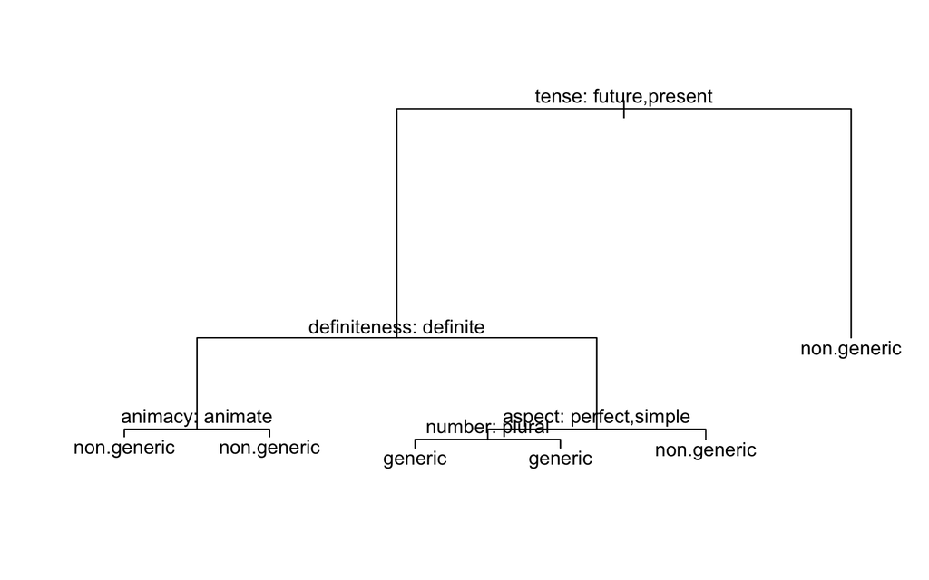

```r
generics.tree = tree(response ~ number + definiteness + animacy + tense +
                       aspect + sentence.length + modal + be.have,data=training)

plot(generics.tree)
text(generics.tree, pretty = 0)
```

How well does this tree do on the test data?

```r
tree.pred = predict(generics.tree, testing, type = "class")

sum(tree.pred == testing$response)/length(tree.pred)
```

```
## [1] 0.8747535
```

Now use cross-validation to see if we might improve misclassification rate by pruning the tree.

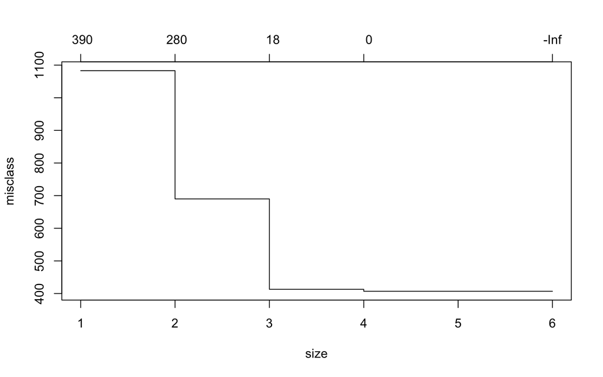

```r
pruning.cv = cv.tree(generics.tree, FUN = prune.misclass)
plot(pruning.cv)
```

Trees of size 3 perform as well as larger trees. Let’s see how well such trees performs on the test data.

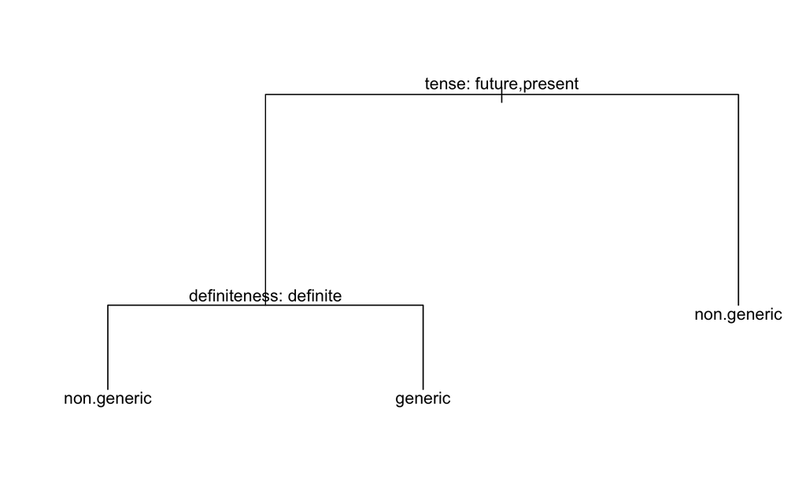

```r
pruned.tree.3 = prune.misclass(generics.tree, best = 3)

plot(pruned.tree.3)
text(pruned.tree.3, pretty = 0,splits=T)
```

```r
tree.pred.3 = predict(pruned.tree.3, testing, type = "class")
sum(tree.pred.3 == testing$response)/length(tree.pred.3)
```

```
## [1] 0.8658777
```

Alternative decision tree:

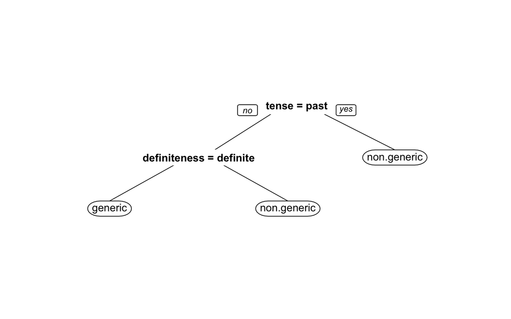

```r
rpart.tree = rpart(response ~ number + definiteness + animacy + tense +
                      aspect + sentence.length + modal + be.have,data=training,
                      method='class')

rpart.prune = prune(rpart.tree,cp=0.1)

prp(rpart.prune,varlen=0,faclen=0,left=F)
```

```r
rpart.pred = predict(rpart.prune,newdata=testing,type='class')
sum(rpart.pred == testing$response)/length(rpart.pred)
```

```
## [1] 0.8658777
```

```r
pdf("../cogsci-2016/figures/tree.pdf", width=4, height=3)
prp(rpart.prune,varlen=0,faclen=0,left=F)
dev.off()
```

## Random Forests

Now let’s try random forests. For this, we build many decision trees based on bootstrapped training samples. Predictions are made by averaging the predictions of all decision trees. In addition, if `p` is the total number of predictors in our data, we choose some value `m < p` and only allow the decision trees to split on some random set of `m` predictors.

```r
generics.rf = train(response ~ number + definiteness + animacy + tense +
                       aspect + sentence.length + modal + be.have,
                    method = 'rf',
                    data=training,
                    trControl = fitControl,
                    tuneGrid = expand.grid(mtry = seq(1:5)),
                    allowParallel=TRUE)

varImp(generics.rf)
```

```
## rf variable importance
##
##                        Overall
## definitenessindefinite 100.000
## tensepast               95.201
## tensepresent            93.621
## be.haveyes               8.294
## sentence.length          6.256
## numbersingular           5.799
## modalyes                 5.015
## aspectprogressive        4.228
## animacyinanimate         2.868
## aspectsimple             0.000
```

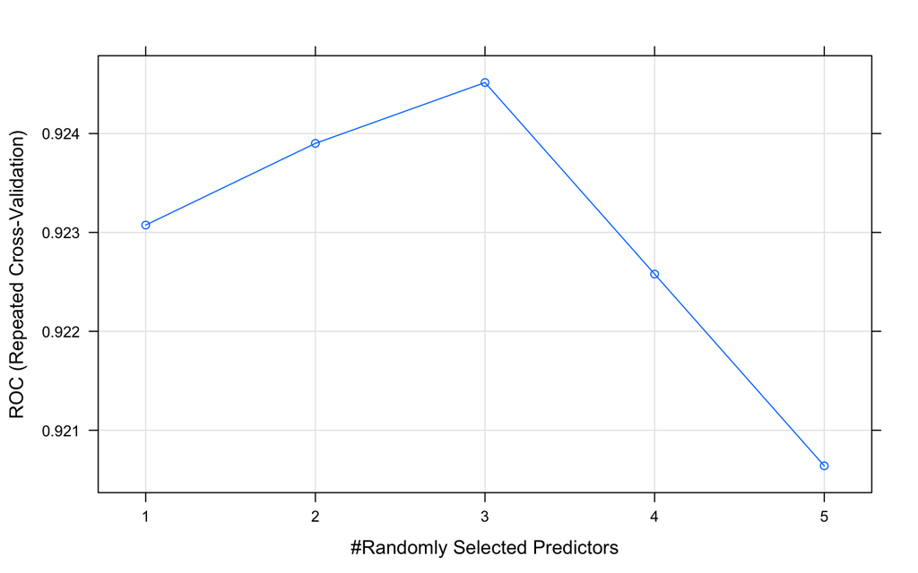

```r
plot(generics.rf)
```

Again, definiteness and tense are the most important factors. It looks like we achieve the best accuracy on the training data for `m=3`. Let’s see how this random forest performs on test data.

```r
rf.classes <- predict(generics.rf, newdata = testing)
confusionMatrix(data = rf.classes, testing$response)
```

```
## Confusion Matrix and Statistics
##
##              Reference
## Prediction    generic non.generic
##   generic         289          55
##   non.generic      71         599
##
##                Accuracy : 0.8757
##                  95% CI : (0.8538, 0.8954)
##     No Information Rate : 0.645
##     P-Value [Acc > NIR] : <2e-16
##
##                   Kappa : 0.7259
##  Mcnemar's Test P-Value : 0.1814
##
##             Sensitivity : 0.8028
##             Specificity : 0.9159
##          Pos Pred Value : 0.8401
##          Neg Pred Value : 0.8940
##              Prevalence : 0.3550
##          Detection Rate : 0.2850
##    Detection Prevalence : 0.3393
##       Balanced Accuracy : 0.8593
##
##        'Positive' Class : generic
##
```

Test accuracy has increased slightly, but it is still comparable to what we had with the simple decision trees.

## Boosting

Rather than fit multiple decision trees to the training data, boosting first fits one decision tree to the training data. This tree is then shrunk and residuals are computed. Additional trees are fit to the residuals of the existing model, shrunk, and added to the current model. This process is then repeated.

```r
generics.boost = train(response ~ number * definiteness + animacy + tense +
                       aspect + sentence.length + modal + be.have,
                      data=training,
                      method = 'gbm',
                      distribution = 'bernoulli',
                      trControl = fitControl,
                      tuneGrid = expand.grid(n.trees = seq(100,1000,100),
                                       interaction.depth = seq(1:5),
                                       shrinkage=.01,
                                       n.minobsinnode=20),
                      verbose = FALSE)

varImp(generics.boost)
```

```
## gbm variable importance
##
##                                       Overall
## tensepast                             100.000
## definitenessindefinite                 56.622
## tensepresent                           13.671
## sentence.length                         8.369
## numbersingular                          7.575
## animacyinanimate                        5.812
## be.haveyes                              4.662
## aspectprogressive                       4.119
## modalyes                                3.498
## aspectsimple                            1.605
## numbersingular:definitenessindefinite   0.000
```

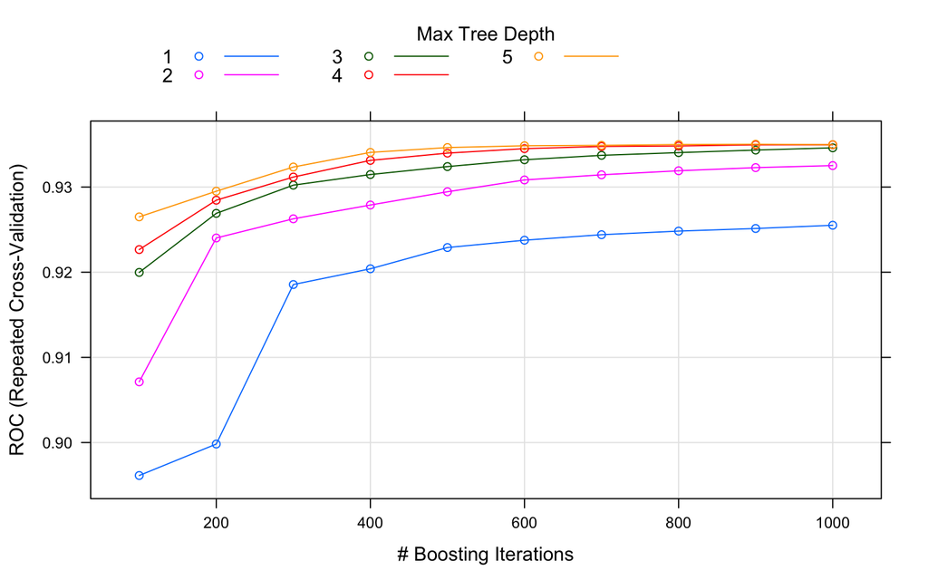

```r
plot(generics.boost)
```

Again, tense and definiteness are the most important factors.

```r
boost.classes <- predict(generics.boost, newdata = testing)
confusionMatrix(data = boost.classes, testing$response)
```

```
## Confusion Matrix and Statistics
##
##              Reference
## Prediction    generic non.generic
##   generic         289          54
##   non.generic      71         600
##
##                Accuracy : 0.8767
##                  95% CI : (0.8549, 0.8963)
##     No Information Rate : 0.645
##     P-Value [Acc > NIR] : <2e-16
##
##                   Kappa : 0.7279
##  Mcnemar's Test P-Value : 0.1524
##
##             Sensitivity : 0.8028
##             Specificity : 0.9174
##          Pos Pred Value : 0.8426
##          Neg Pred Value : 0.8942
##              Prevalence : 0.3550
##          Detection Rate : 0.2850
##    Detection Prevalence : 0.3383
##       Balanced Accuracy : 0.8601
##
##        'Positive' Class : generic
##
```

Test accuracy is comparable to what we saw for basic decision trees and random forests.